# Transform Data

# Introduction

This work through builds on from **Tidy Data**. Here we explore more of babynames e.g. make plots by names of babies rather than just by gender.

```r
library(tidyverse)
library(babynames)
library(nycflights13)
# Toy datasets to use
pollution <- tribble(
       ~city,   ~size, ~amount,
  "New York", "large",      23,
  "New York", "small",      14,
    "London", "large",      22,
    "London", "small",      16,
   "Beijing", "large",      121,
   "Beijing", "small",      56
)
band <- tribble(
   ~name,     ~band,
  "Mick",  "Stones",
  "John", "Beatles",
  "Paul", "Beatles"
)
instrument <- tribble(
    ~name,   ~plays,
   "John", "guitar",
   "Paul",   "bass",
  "Keith", "guitar"
)
instrument2 <- tribble(
    ~artist,   ~plays,
   "John", "guitar",
   "Paul",   "bass",
  "Keith", "guitar"
)
```

## babynames

| year | sex | name | n | prop |
| --- | --- | --- | --- | --- |
| 1880 | F | Mary | 7065 | 0.07238359 |
| 1880 | F | Anna | 2604 | 0.02667896 |
| 1880 | F | Emma | 2003 | 0.02052149 |

## Your Turn 1

You can isolate data by using:

**select()** - extract variables

**filter()** - extract cases

**arrange()** - reorder cases

Use `select()` to get just the `n` column:

```r
# select(babynames, name, n) # gives us names and n column
select(babynames, n) # this is just column n
```

| n |
| --- |
| 7065 |
| 2604 |
| 2003 |
| 1939 |
| 1746 |
| 1578 |
| 1472 |
| 1414 |
| 1320 |
| 1288 |

[output cut: 990 more lines]

## Quiz

Which of these is NOT a way to select the `name` and `n` columns together?

```r
select(babynames, -c(year, sex, prop)) # yes - this would work. The -c() REMOVES the columns specified
```

| name | n |
| --- | --- |
| Mary | 7065 |
| Anna | 2604 |
| Emma | 2003 |
| Elizabeth | 1939 |
| Minnie | 1746 |
| Margaret | 1578 |
| Ida | 1472 |
| Alice | 1414 |
| Bertha | 1320 |
| Sarah | 1288 |

[output cut: 990 more lines]

```r
select(babynames, name:n) # yes - this would work. Names the columns we want to select from column "name"" through to column "n"
```

| name | n |
| --- | --- |
| Mary | 7065 |
| Anna | 2604 |
| Emma | 2003 |
| Elizabeth | 1939 |
| Minnie | 1746 |
| Margaret | 1578 |
| Ida | 1472 |
| Alice | 1414 |
| Bertha | 1320 |
| Sarah | 1288 |

[output cut: 990 more lines]

```r
select(babynames, starts_with("n")) # yes - this would work as both columns "name" and "n" begin with the character "n"
```

| name | n |
| --- | --- |
| Mary | 7065 |
| Anna | 2604 |
| Emma | 2003 |
| Elizabeth | 1939 |
| Minnie | 1746 |
| Margaret | 1578 |
| Ida | 1472 |
| Alice | 1414 |
| Bertha | 1320 |
| Sarah | 1288 |

[output cut: 990 more lines]

```r
select(babynames, ends_with("n")) # no - this would just get column "n"
```

| n |
| --- |
| 7065 |
| 2604 |
| 2003 |
| 1939 |
| 1746 |
| 1578 |
| 1472 |
| 1414 |
| 1320 |
| 1288 |

[output cut: 990 more lines]

```r
select(babynames, contains("n")) # yes - only columns "name" and "n" contain the character "n"
```

| name | n |
| --- | --- |
| Mary | 7065 |
| Anna | 2604 |
| Emma | 2003 |
| Elizabeth | 1939 |
| Minnie | 1746 |
| Margaret | 1578 |
| Ida | 1472 |
| Alice | 1414 |
| Bertha | 1320 |
| Sarah | 1288 |

[output cut: 990 more lines]

Other useful things you can do with the `select()` function to extract the columns of interest are:

**matches()** - Select columns whose names match a regular expression. Note that regular expresssion should be in " ". In this example **select(data, matches("^.{4}$"))** would mean select columns which match with the regular expression of the same four characters. See here for more information on how regular expressions work! **This is a super useful topic https://regex101.com/**

**one_of()** - Select columns whose names are one of a set for example **select(storms, one_of(c("storm", "storms", "Storm"))**

**num_range()** - Select columns named in prefix, number style for example **select(storms, num_range("x", 1:5))**

## Your Turn 2

Show:

- All of the names where prop is greater than or equal to 0.08
- All of the children named "Sea"
- All of the names that have a missing value for `n`

To do this we need to use **filter()** which gives us the rows or interest. **NB:** `select()` gives us the columns of interet.

| year | sex | name | n | prop |
| --- | --- | --- | --- | --- |
| 2015 | F | Emma | 20435 | 0.01050471 |
| 2015 | M | Emma | 10 | 0.00000491 |
| 2016 | F | Emma | 19471 | 0.01009677 |
| 2016 | M | Emma | 18 | 0.00000892 |
| 2017 | F | Emma | 19738 | 0.01052750 |
| 2017 | M | Emma | 14 | 0.00000713 |

Useful terms:

**x < y** Less than

**x > y** Greater than

**x == y** Equal to

**x <= y** Less than or equal to

**x >= y** Greater than or equal to

**x != y** Not equal to

**x %in% y** Group membership e.g. group of names

**is.na(x)** Is NA

**!is.na(x)** Is not NA

| year | sex | name | n | prop |
| --- | --- | --- | --- | --- |
| 1880 | F | Alice | 1414 | 0.01448696 |
| 1880 | F | Sarah | 1288 | 0.01319605 |
| 1880 | M | Ben | 305 | 0.00257601 |
| 1881 | F | Alice | 1308 | 0.01323150 |
| 1881 | F | Sarah | 1226 | 0.01240200 |
| 1881 | M | Ben | 289 | 0.00266896 |
| 1881 | M | Alice | 7 | 0.00006465 |
| 1882 | F | Alice | 1542 | 0.01332815 |
| 1882 | F | Sarah | 1410 | 0.01218722 |
| 1882 | M | Ben | 334 | 0.00273701 |

[output cut: 687 more lines]

Note that you can also use multiple arguements with `filter()` such as name and year

| year | sex | name | n | prop |
| --- | --- | --- | --- | --- |
| 1987 | F | Emma | 1588 | 0.00084746 |
| 1987 | M | Emma | 9 | 0.00000462 |

Boolean operators enable us to specify multiple arguements in filter with more precision, such as using "and" and "or". Where:

**a & b** = and

**a | b** = or

**xor(a,b)** = "exclusive or". It is a logical operation that is true if and only if its arguments differ (one is true, the other is false). e.g. Returns true if a but not b; or if b but not a. Returns false if not a and not b; returns false if a and b.

**!a** = not

## Your Turn 3

Use Boolean operators to alter the code below to return only the rows that contain:

- Girls named Sea
- Names that were used by exactly 5 or 6 children in 1880
- Names that are one of Acura, Lexus, or Yugo

```r
filter(babynames, name == "Sea" & sex == "F") # females with name Sea
```

| year | sex | name | n | prop |
| --- | --- | --- | --- | --- |
| 1982 | F | Sea | 5 | 2.76e-06 |
| 1998 | F | Sea | 5 | 2.58e-06 |

```r
filter(babynames, n == 5 | n == 6 & year == 1880) # n is 5 or 6 and year is 1880
```

| year | sex | name | n | prop |
| --- | --- | --- | --- | --- |
| 1880 | F | Abby | 6 | 6.147e-05 |
| 1880 | F | Aileen | 6 | 6.147e-05 |
| 1880 | F | Alba | 6 | 6.147e-05 |
| 1880 | F | Alda | 6 | 6.147e-05 |
| 1880 | F | Alla | 6 | 6.147e-05 |
| 1880 | F | Alverta | 6 | 6.147e-05 |
| 1880 | F | Ara | 6 | 6.147e-05 |
| 1880 | F | Ardelia | 6 | 6.147e-05 |
| 1880 | F | Ardella | 6 | 6.147e-05 |
| 1880 | F | Arrie | 6 | 6.147e-05 |

[output cut: 990 more lines]

```r
filter(babynames, name %in% c("Acura", "Lexus", "Yugo"))
```

| year | sex | name | n | prop |
| --- | --- | --- | --- | --- |
| 1990 | F | Lexus | 36 | 0.00001753 |
| 1990 | M | Lexus | 12 | 0.00000558 |
| 1991 | F | Lexus | 102 | 0.00005017 |
| 1991 | M | Lexus | 16 | 0.00000755 |
| 1992 | F | Lexus | 193 | 0.00009629 |
| 1992 | M | Lexus | 25 | 0.00001191 |
| 1993 | F | Lexus | 285 | 0.00014458 |
| 1993 | M | Lexus | 30 | 0.00001453 |
| 1994 | F | Lexus | 381 | 0.00019548 |
| 1994 | F | Acura | 6 | 0.00000308 |

[output cut: 47 more lines]

Using `subset()` instead of filter can give similar results. Here we want to subset (or filter) our data to give female names with more than 25 records. Additionally we have selected to show only the year and name columns.

```r
# using subset() and select()
subset(babynames, sex=="F" & n > 25,
select=c(year, name))
```

| year | name |
| --- | --- |
| 1880 | Mary |
| 1880 | Anna |
| 1880 | Emma |
| 1880 | Elizabeth |
| 1880 | Minnie |
| 1880 | Margaret |
| 1880 | Ida |
| 1880 | Alice |
| 1880 | Bertha |
| 1880 | Sarah |

[output cut: 990 more lines]

```r
# using filter(), select() and pipe function
babynames %>%
  filter(sex == "F" & n > 25) %>%
  select(c(year, name))
```

| year | name |
| --- | --- |
| 1880 | Mary |
| 1880 | Anna |
| 1880 | Emma |
| 1880 | Elizabeth |
| 1880 | Minnie |
| 1880 | Margaret |
| 1880 | Ida |
| 1880 | Alice |
| 1880 | Bertha |
| 1880 | Sarah |

[output cut: 990 more lines]

## Your Turn 4

You can manipulate data further using **arrange()** for example to: Order rows from smallest to largest values.

Arrange babynames by `n`. Add `year` as a second (tie breaking) variable to arrange on. Can you tell what the smallest value of `n` is?

```r
babynames %>%
  arrange(n) # arranges data by column n from smalles to largest
```

| year | sex | name | n | prop |
| --- | --- | --- | --- | --- |
| 1880 | F | Adelle | 5 | 5.123e-05 |
| 1880 | F | Adina | 5 | 5.123e-05 |
| 1880 | F | Adrienne | 5 | 5.123e-05 |
| 1880 | F | Albertine | 5 | 5.123e-05 |
| 1880 | F | Alys | 5 | 5.123e-05 |
| 1880 | F | Ana | 5 | 5.123e-05 |
| 1880 | F | Araminta | 5 | 5.123e-05 |
| 1880 | F | Arthur | 5 | 5.123e-05 |
| 1880 | F | Birtha | 5 | 5.123e-05 |
| 1880 | F | Bulah | 5 | 5.123e-05 |

[output cut: 990 more lines]

```r
babynames %>%
  arrange(n, year) # as above, but also does this with the year column too
```

| year | sex | name | n | prop |
| --- | --- | --- | --- | --- |
| 1880 | F | Adelle | 5 | 5.123e-05 |
| 1880 | F | Adina | 5 | 5.123e-05 |
| 1880 | F | Adrienne | 5 | 5.123e-05 |
| 1880 | F | Albertine | 5 | 5.123e-05 |
| 1880 | F | Alys | 5 | 5.123e-05 |
| 1880 | F | Ana | 5 | 5.123e-05 |
| 1880 | F | Araminta | 5 | 5.123e-05 |
| 1880 | F | Arthur | 5 | 5.123e-05 |
| 1880 | F | Birtha | 5 | 5.123e-05 |
| 1880 | F | Bulah | 5 | 5.123e-05 |

[output cut: 990 more lines]

## Your Turn 5

You can alter the way that `arrange()` works by specifying as argument to the column of interest such as **desc()** for **DESCENDING** order (largest to smallest). By default, `arrange()` orders from smallest to largest.

Use `desc()` to find the names with the highest prop. Then, use `desc()` to find the names with the highest n.

| year | sex | name | n | prop |
| --- | --- | --- | --- | --- |
| 1880 | M | John | 9655 | 0.08154561 |
| 1881 | M | John | 8769 | 0.08098299 |
| 1880 | M | William | 9532 | 0.08050676 |
| 1883 | M | John | 8894 | 0.07907394 |
| 1881 | M | William | 8524 | 0.07872038 |
| 1882 | M | John | 9557 | 0.07831617 |
| 1884 | M | John | 9388 | 0.07648813 |
| 1882 | M | William | 9298 | 0.07619375 |
| 1886 | M | John | 9026 | 0.07582262 |
| 1885 | M | John | 8756 | 0.07551856 |

[output cut: 990 more lines]

## Your Turn 6

Use `%>%` to write a sequence of functions that:

1. Filter babynames to just the girls that were born in 2015
2. Select the `name` and `n` columns
3. Arrange the results so that the most popular names are near the top.

| name | n |
| --- | --- |
| Emma | 20435 |
| Olivia | 19669 |
| Sophia | 17402 |
| Ava | 16361 |
| Isabella | 15594 |
| Mia | 14892 |
| Abigail | 12390 |
| Emily | 11780 |
| Charlotte | 11390 |
| Harper | 10291 |

[output cut: 990 more lines]

**NOTE!** You can use the short cut `Ctrl`+`shift`+`m` to give you the pipe function

```r
%>%
```

Note that if this was a mac would have to code using `Cmd`+`shift`+`m`

## Exam

1. Trim `babynames` to just the rows that contain your `name` and your `sex`
2. Trim the result to just the columns that will appear in your graph (not strictly necessary, but useful practice)
3. Plot the results as a line graph with `year` on the x axis and `prop` on the y axis

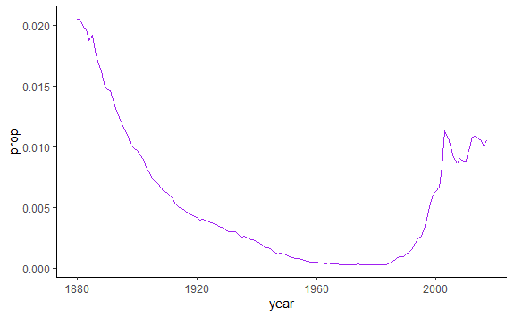

## Your Turn 7

Use `summarise()` to compute three statistics about the data:

1. The first (minimum) year in the dataset
2. The last (maximum) year in the dataset
3. The total number of children represented in the data

| year_min | year_max | Tchildren |
| --- | --- | --- |
| 1880 | 2017 | 348120517 |

## Your Turn 8

Extract the rows where `name == "Khaleesi"`. Then use `summarise()` and a summary functions to find:

1. The total number of children named Khaleesi
2. The first year Khaleesi appeared in the data

| Tchildren | year_min | year_max |
| --- | --- | --- |
| 1964 | 2011 | 2017 |

## Your Turn 9

A name is popular if: 1. Sums - a large number of children have the name when you sum across years 2. Ranks - it consistently ranks among the top names from year to year.

| year | max |
| --- | --- |
| 1880 | 9655 |
| 1881 | 8769 |
| 1882 | 9557 |
| 1883 | 8894 |
| 1884 | 9388 |
| 1885 | 9128 |
| 1886 | 9889 |
| 1887 | 9888 |
| 1888 | 11754 |
| 1889 | 11648 |

[output cut: 128 more lines]

We can calculate the most popular names from `babynames` using:

**summarise()** - summarise variables

**group_by()** - group cases

**mutate()** - create new variables

Use `group_by()`, `summarise()`, and `arrange()` to display the ten most popular names. Compute popularity as the total number of children of a single gender given a name.

## Your Turn 10

Use grouping to calculate and then plot the number of children born each year over time.

## Your Turn 11

Use `min_rank()` and `mutate()` to rank each row in `babynames` from largest `n` to lowest `n`.

## Your Turn 12

Compute each name's rank *within its year and sex*. Then compute the median rank *for each combination of name and sex*, and arrange the results from highest median rank to lowest.

## Your Turn 13

Which airlines had the largest arrival delays? Complete the code below.

1. Join `airlines` to `flights`
2. Compute and order the average arrival delays by airline. Display full names, no codes.

```r
flights %>%
  drop_na(arr_delay) %>%
                      %>%
  group_by(         ) %>%
                      %>%
  arrange(       )
```

## Your Turn 14

How many airports in `airports` are serviced by flights originating in New York (i.e. flights in our dataset?) Notice that the column to join on is named `faa` in the **airports** data set and `dest` in the **flights** data set.

```r
__________ %>%
 _________(_________, by = ___________) %>%
  distinct(faa)
```

# Take aways

- Extract variables with `select()`
- Extract cases with `filter()`
- Arrange cases, with `arrange()`
- Make tables of summaries with `summarise()`
- Make new variables, with `mutate()`
- Do groupwise operations with `group_by()`
- Connect operations with `%>%`
- Use `left_join()`, `right_join()`, `full_join()`, or `inner_join()` to join datasets
- Use `semi_join()` or `anti_join()` to filter datasets against each other